# Lab #2 - Plotting with `ggplot2`

# Overview of ggplot2

The `ggplot2` package is intended to follow “grammar of graphics” made of independent components that can be added together to build plot. Every ggplot2 plot has three components:

1. Data – the information we wish to visually represent
2. Aesthetics – A map between the data and visual properties, e.g., xy axes, color, shape, etc.
3. Layers – How each of the observations in the data is rendered, e.g., scatterplot, box plot, etc.,

This lab will be a first exploration into what these components are and how they relate to the construction of publication-ready graphics.

## Data

For this lab, we will be using the `mpg` dataset that is included in the `ggplot2` package. This dataset contains a subset of fuel economy data that the EPA collected for various car models in 1999 and 2008. We begin with a quick visual inspection of the variables in our dataset:

```r
library(ggplot2) # load package first

## head() will examine the first few rows of a data.frame
head(mpg)
```

```
## # A tibble: 6 × 11
##   manufacturer model displ  year   cyl trans      drv     cty   hwy fl    class
##   <chr>        <chr> <dbl> <int> <int> <chr>      <chr> <int> <int> <chr> <chr>
## 1 audi         a4      1.8  1999     4 auto(l5)   f        18    29 p     compa…
## 2 audi         a4      1.8  1999     4 manual(m5) f        21    29 p     compa…
## 3 audi         a4      2    2008     4 manual(m6) f        20    31 p     compa…
## 4 audi         a4      2    2008     4 auto(av)   f        21    30 p     compa…
## 5 audi         a4      2.8  1999     6 auto(l5)   f        16    26 p     compa…
## 6 audi         a4      2.8  1999     6 manual(m5) f        18    26 p     compa…
```

A description of all of the variables can be read with `?mpg`.

## Aesthetics

Consider the scatterplot below constructed from the `mpg` dataset:

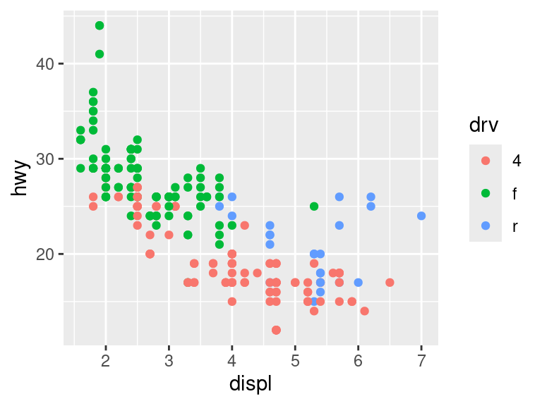

Here, each observation is represented by a point, the *vertical* and *horizontal* positions being determined by the value of two variables (`displ` and `hwy`), and a color determined by a third (`drv`). Conceivably, the size and shapes of the points could be associated with variables in the data.frame as well. These attributes to a graph are called **aesthetics** and represent a *mapping* from the variables in the data to visual properties in a graph. This will be an important point to keep in the back of our minds as our aesthetics becoming increasingly more detailed.

Every plot we construct will begin with a call to `ggplot()`, with the first argument always given as the data.frame. Without defining any aesthetics, though, all we are left with is a space that is reserved for our eventual graphic.

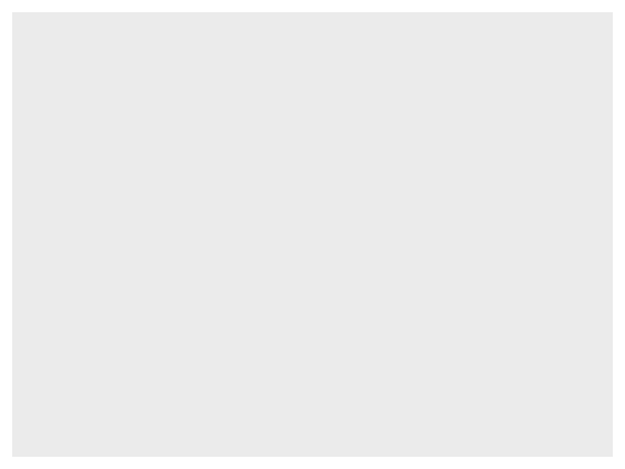

```r
## An empty ggplot with no aesthetics
ggplot(mpg)
```

Let’s start by establishing the X and Y positions for our graph based on their respective variables. We add aesthetics with the `aes()` function:

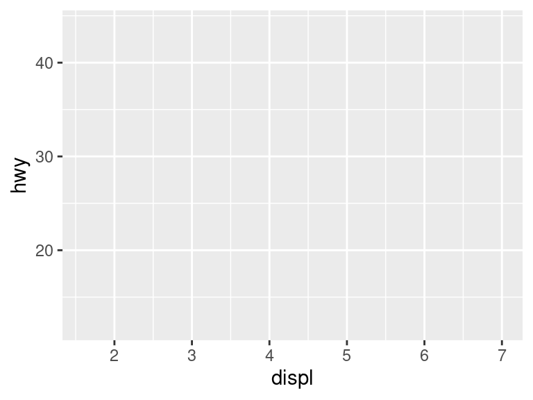

```r
## Every ggplot begins with ggplot()
ggplot(mpg, aes(x = displ, y = hwy))
```

The resulting plot is a simple XY plane with `displ` set as the x-axis and `hwy` set as the y axes. Further, note that the range of the x and y axes are already determined based on the ranges of values for the variables in `mpg`. This is what we mean when we say that the aesthetics represent a map from the data itself to the construction of our plot.

We also see here that while the `aes()` function creates a map from the variables to graphical aesthetics, it doesn’t actually add any of our observed data. This is done with *layers*, the topic of the next section.

## Layers

We can think of layers as being the particular details of how we want our data to be portrayed on the ggplot. These can range from simple plots of the xy coordinates as in a scatter plot to more detailed summaries of the data. Notably, a ggplot can have an arbitrary number of layers added to it, which we “add” to a plot with `+`. For example, let’s add a layer to the previous graph that allows us to see our observed data as points. We do this with `geom_point()`.

When adding layers to a ggplot, it is best practice to end a line with `+` and only include one additional layer on each subsequent line

```r
## Best practice is to end each line with a `+` and including only one layer per line
ggplot(mpg, aes(x = displ, y = hwy)) +
  geom_point()
```

[output not shown]

Compared with the plot above, note that we still have the same xy-coordinate system generated with `ggplot(mpg, aes(displ, hwy))`, but we have now “added” a layer of scatter points that sit on top of the initial plot. We can continue like this constructively, adding as many layers as we wish. For example, we can add an additional layer showing a fitted line that sits “on top” of the points

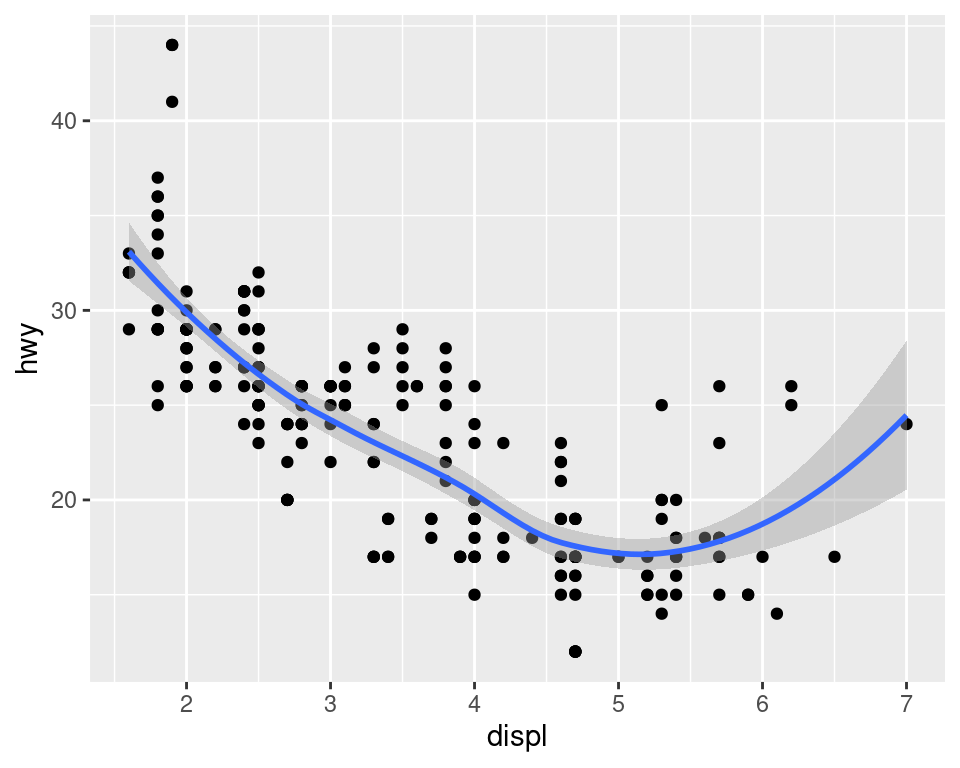

```r
## Adding an additional layer
ggplot(mpg, aes(x = displ, y = hwy)) +
  geom_point() +
  geom_smooth()
```

As we continue working with ggplot, this will be a helpful way to think about the process.

**Question 1:** What happens when you change the order of the layers for a given plot? Try with the plot above and comment on the difference.

**Question 2:** Consider the plot below, and identify the *data*, the *aesthetics*, and the *layers* that are used to build the plot

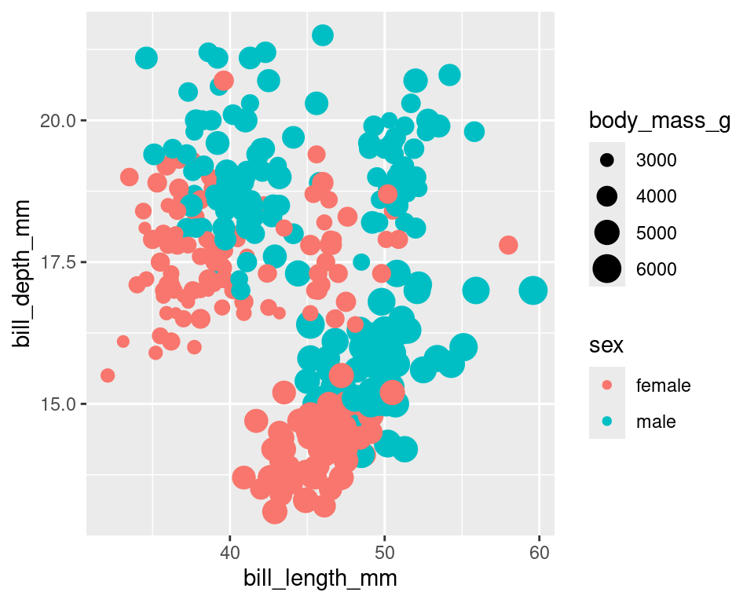

```r
## Penguin dataset
pengy <- read.csv("https://collinn.github.io/data/penguins.csv")

ggplot(pengy, aes(x = bill_length_mm, y = bill_depth_mm,
                  size = body_mass_g, color = sex)) +
  geom_point()
```

Most (but not all) layers that we might add in ggplot begin with `geom_` to help indicate that they can be thought of as the actual, geometric elements (lines, points, etc.,) that you will see on the plot. In addition to `geom_point()`, there are a few others that are worth being aware of:

- `geom_point` - scatter plots
- `geom_jitter` – scatter plot with “jittered” coordinates
- `geom_bar` - bar graph for categorical data
- `geom_smooth` - smoother for data
- `geom_boxplot` - box plot
- `geom_histogram` - histograms
- `geom_violin` - violin plot

**Question 3:** Use `geom_boxplot()` to create a box plot with the `mpg` data with the `class` variable on the x-axis and `hwy` on the y-axis.

## Working with Groups

Plots are primarily generated to quickly convey interesting relationships that exist in our data. In the scatter plot we just generated, we are immediately able to see that as an engine’s displacement size increases, the highway fuel economy begins to de crease. One question we may have is whether or not this pattern is the same across multiple types of vehicles. Or, more generally, we are asking if this same trend persists across different *groupings* of our data. We can ask questions like this by modifying the aesthetics of our plots.

A standard XY plot has two dimensions (one horizontal, one vertical), but we can add a third dimension that incorporates color into our figure. Here, we set the color to group by drive train (four wheel drive, front wheel drive, rear wheel drive) using a color argument in `aes()` and setting it equal to the variable `drv`

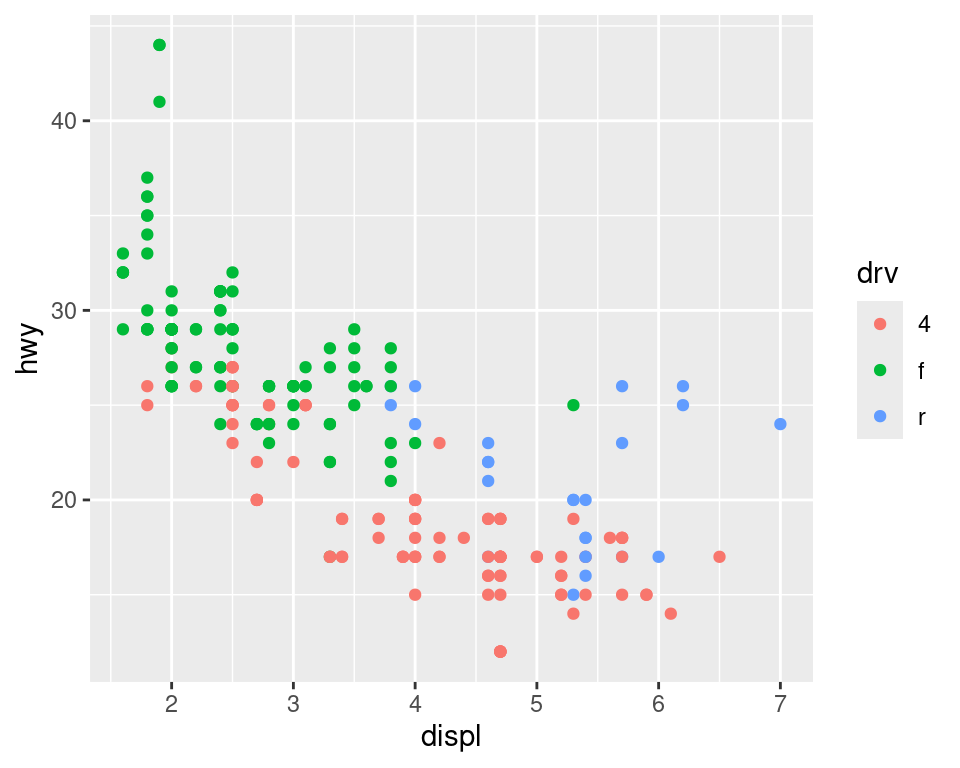

```r
ggplot(mpg, aes(displ, hwy, color = drv)) +
  geom_point()
```

In addition to color, we can also set the shapes of the points. And so long as we use the same grouping variable for each, we can combine this aesthetic with color:

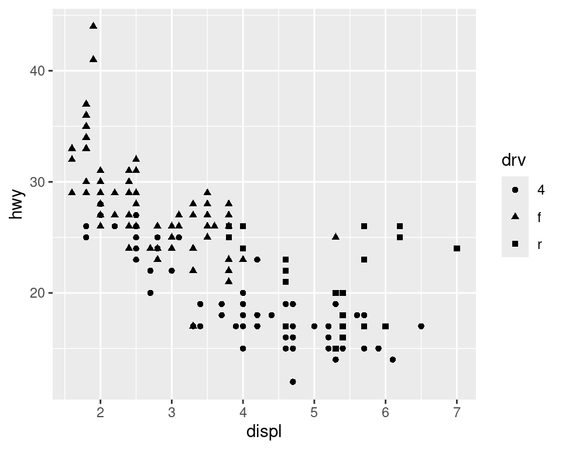

```r
## Using shapes instead of color
ggplot(mpg, aes(displ, hwy, shape = drv)) +
  geom_point()
```

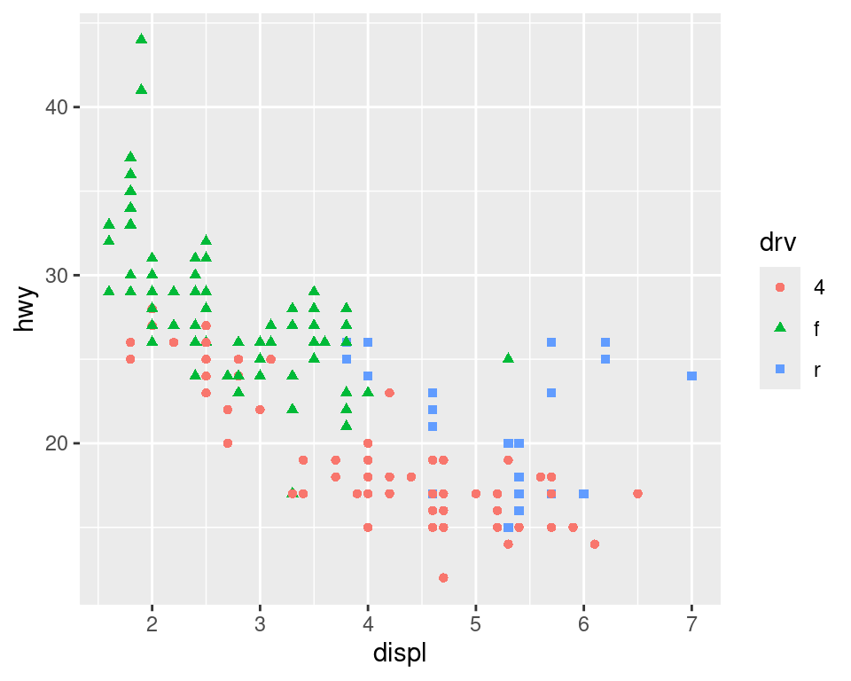

```r
## We can have multiple aesthetics combined in legend
ggplot(mpg, aes(displ, hwy, color = drv, shape = drv)) +
  geom_point()
```

We can also combine aesthetics for different groups, adding a fourth dimension to our data. In addition to asking about the drive train when considering the relationship between displacement and fuel economy, we could also consider groups based on the vehicles’ class

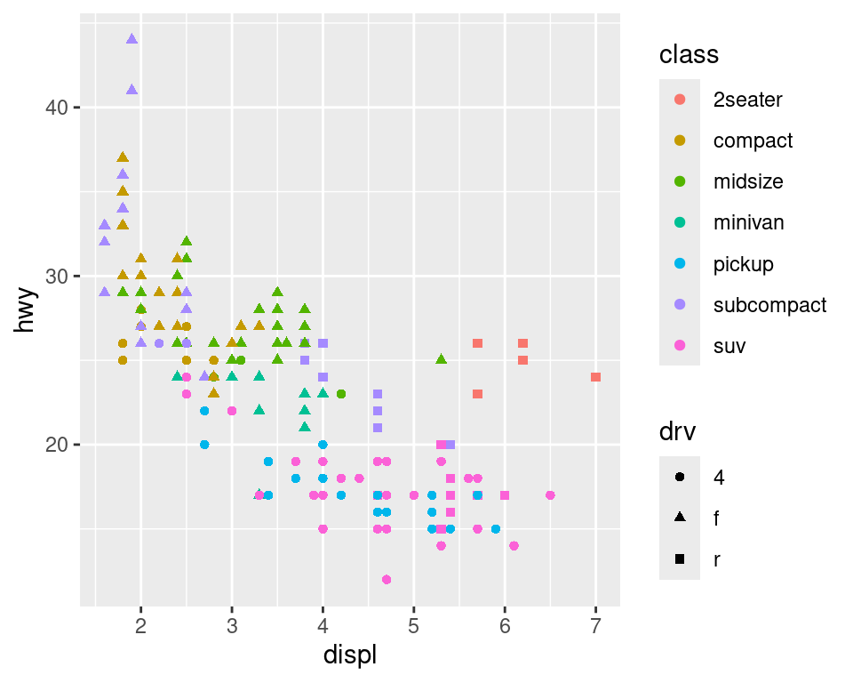

```r
ggplot(mpg, aes(displ, hwy, color = class, shape = drv)) +
  geom_point()
```

While this is technically correct, we run the risk of overloading our plot, making it difficult to interpret in any useful way. Instead of adding an additional aesthetic to our plot, we can instead use a technique known as *faceting* to split our plot across multiple groups. Here, we recreate the plot above except facet on the `drv` variable rather than plot its shape. We do this with the function `facet_wrap()` which takes its argument in the form `~variable` (note the tilde)

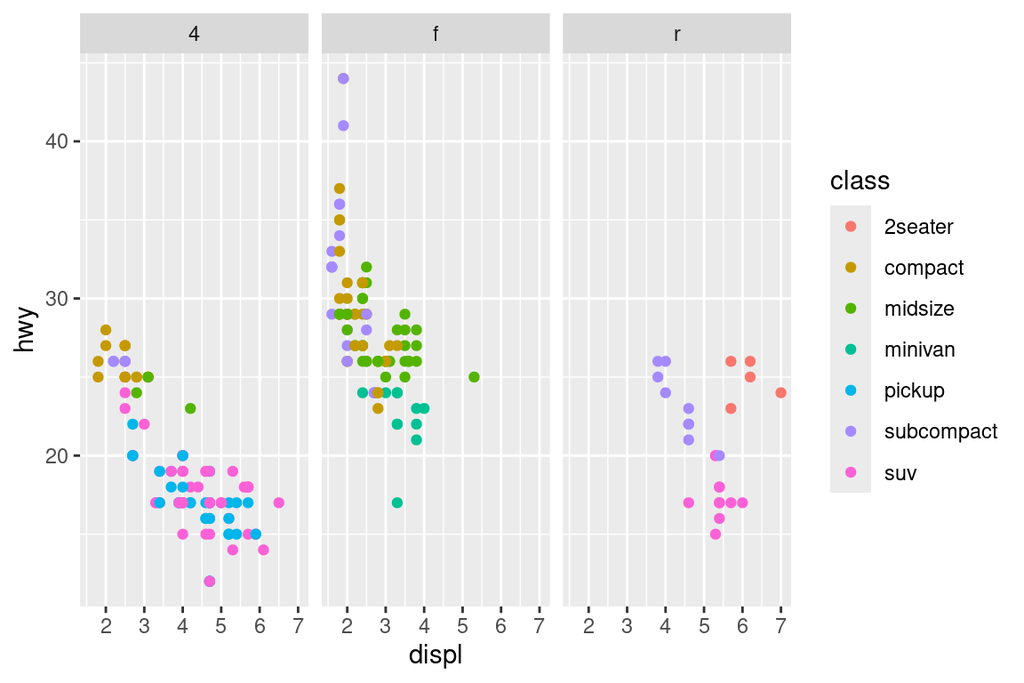

```r
ggplot(mpg, aes(displ, hwy, color = class)) +
  geom_point() +
  facet_wrap(~drv)
```

**Question 4:** When faceting, should our variable be quantitative, categorical, or does it not matter?

**Question 5:** Use the penguin dataset below to create a ggplot that is faceted on a variable. Describe what the plot shows in a few sentences.

## Variable Types and Aesthetics

As we saw above, there are some aesthetics that, when set, appear to create discrete groupings of the data. This behavior, however, is contingent on the aesthetic mapping being towards a variable that is categorical or discrete in nature. For example, suppose we are interested again in the relationship between engine displacement and highway fuel economy, except this time we want to group it by the number of cylinders a vehicle has. We might create something like this:

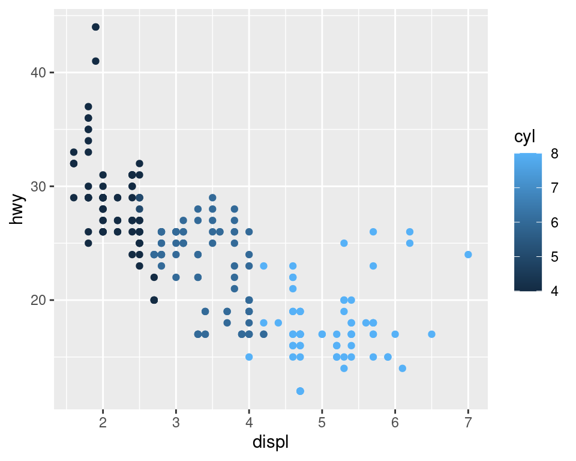

```r
ggplot(mpg, aes(displ, hwy, color = cyl)) +
  geom_point()
```

What do you notice in the legend? Rather than creating a palette of discrete colors, we are left with a gradient of colors from dark to light blue. This is a consequence of the fact that, by default, the variable `cyl` is stored as a numerical variable rather than a categorical one. We can use the function `factor()` to turn a quantitative variable like `cyl` into a categorical one (we will discuss `factor()` in more detail later, but as always, you can investigate how this function behaves with `?factor`)

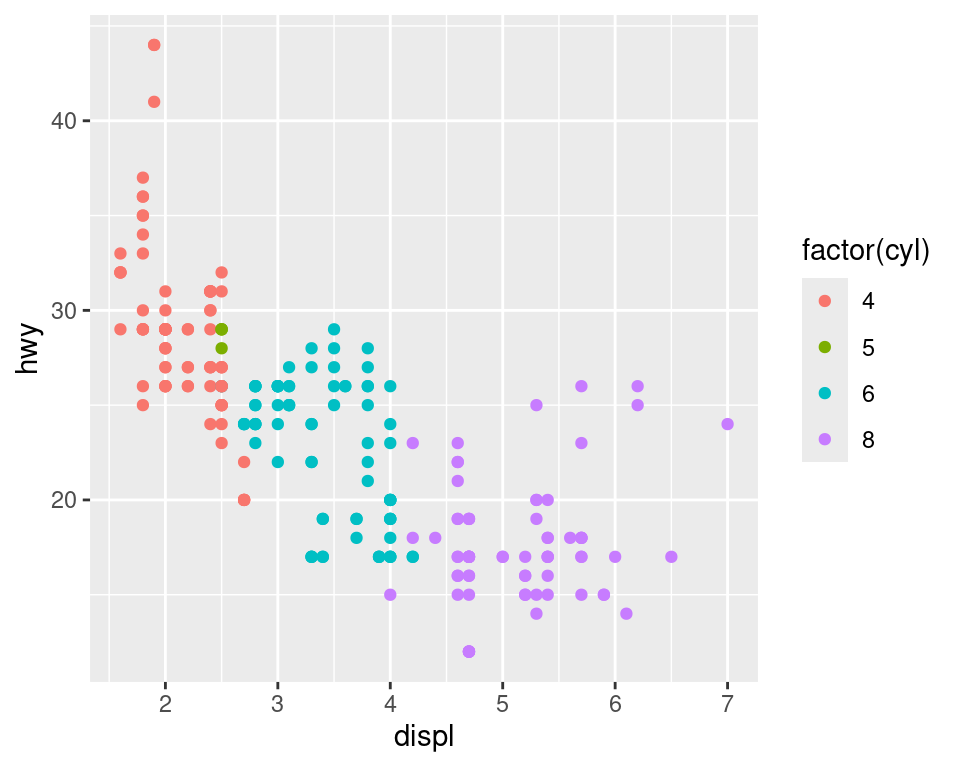

```r
ggplot(mpg, aes(displ, hwy, color = factor(cyl))) +
  geom_point()
```

This is just one example of how the rendering of an aesthetic can change based on the type of variable it is mapped to.

**Question 7:** Create a box plot with `class` as the x axis and hwy as the y. In order to compare these vehicles from when data was first collected to when it was last collected, specify the color aesthetic as `year`. Is this the plot that you would expect? Make whatever modifications necessary to produce the intended graph.